# Bank Marketing Analysis

### The aim of this analysis is to delve into the insights hidden within the banking dataset and address the following research questions:

- a) How do different client attributes, such as age, job type, marital status, and education, impact subscribing to a term deposit?
- b) Are there any observable trends in client contact strategies, such as communication type, month of contact, and day of the week, that impact subscription rates?
- c) What impact does the duration of contact have on the subscription decision?
- d) How does the subscription rate differ between different job types, education levels, and marital statuses?

#### Presented by:

# Mohamed Anwar

```python
import pandas as pd
import numpy as np
import seaborn as sns
import matplotlib.pyplot as plt
import plotly.express as px
import os
os.chdir('C:\\Users\\Anwar\\Desktop')
```

```python
df = pd.read_csv("banking.csv", sep=";", encoding="utf-8")
df
```

|  | age | job | marital | education | default | housing | loan | contact | month | day_of_week | ... | campaign | pdays | previous | poutcome | emp.var.rate | cons.price.idx | cons.conf.idx | euribor3m | nr.employed | y |
| --- | --- | --- | --- | --- | --- | --- | --- | --- | --- | --- | --- | --- | --- | --- | --- | --- | --- | --- | --- | --- | --- |
| 0 | 56 | housemaid | married | basic.4y | no | no | no | telephone | may | mon | ... | 1 | 999 | 0 | nonexistent | 1.1 | 93.994 | -36.4 | 4.857 | 5191.0 | no |
| 1 | 57 | services | married | high.school | unknown | no | no | telephone | may | mon | ... | 1 | 999 | 0 | nonexistent | 1.1 | 93.994 | -36.4 | 4.857 | 5191.0 | no |
| 2 | 37 | services | married | high.school | no | yes | no | telephone | may | mon | ... | 1 | 999 | 0 | nonexistent | 1.1 | 93.994 | -36.4 | 4.857 | 5191.0 | no |
| 3 | 40 | admin. | married | basic.6y | no | no | no | telephone | may | mon | ... | 1 | 999 | 0 | nonexistent | 1.1 | 93.994 | -36.4 | 4.857 | 5191.0 | no |
| 4 | 56 | services | married | high.school | no | no | yes | telephone | may | mon | ... | 1 | 999 | 0 | nonexistent | 1.1 | 93.994 | -36.4 | 4.857 | 5191.0 | no |
| ... | ... | ... | ... | ... | ... | ... | ... | ... | ... | ... | ... | ... | ... | ... | ... | ... | ... | ... | ... | ... | ... |
| 41183 | 73 | retired | married | professional.course | no | yes | no | cellular | nov | fri | ... | 1 | 999 | 0 | nonexistent | -1.1 | 94.767 | -50.8 | 1.028 | 4963.6 | yes |
| 41184 | 46 | blue-collar | married | professional.course | no | no | no | cellular | nov | fri | ... | 1 | 999 | 0 | nonexistent | -1.1 | 94.767 | -50.8 | 1.028 | 4963.6 | no |
| 41185 | 56 | retired | married | university.degree | no | yes | no | cellular | nov | fri | ... | 2 | 999 | 0 | nonexistent | -1.1 | 94.767 | -50.8 | 1.028 | 4963.6 | no |
| 41186 | 44 | technician | married | professional.course | no | no | no | cellular | nov | fri | ... | 1 | 999 | 0 | nonexistent | -1.1 | 94.767 | -50.8 | 1.028 | 4963.6 | yes |
| 41187 | 74 | retired | married | professional.course | no | yes | no | cellular | nov | fri | ... | 3 | 999 | 1 | failure | -1.1 | 94.767 | -50.8 | 1.028 | 4963.6 | no |

41188 rows × 21 columns

```python
df.info()
```

```
<class 'pandas.core.frame.DataFrame'>
RangeIndex: 41188 entries, 0 to 41187
Data columns (total 21 columns):
 #   Column          Non-Null Count  Dtype
---  ------          --------------  -----
 0   age             41188 non-null  int64
 1   job             41188 non-null  object
 2   marital         41188 non-null  object
 3   education       41188 non-null  object
 4   default         41188 non-null  object
 5   housing         41188 non-null  object
 6   loan            41188 non-null  object
 7   contact         41188 non-null  object
 8   month           41188 non-null  object
 9   day_of_week     41188 non-null  object
 10  duration        41188 non-null  int64
 11  campaign        41188 non-null  int64
 12  pdays           41188 non-null  int64
 13  previous        41188 non-null  int64
 14  poutcome        41188 non-null  object
 15  emp.var.rate    41188 non-null  float64
 16  cons.price.idx  41188 non-null  float64
 17  cons.conf.idx   41188 non-null  float64
 18  euribor3m       41188 non-null  float64
 19  nr.employed     41188 non-null  float64
 20  y               41188 non-null  object
dtypes: float64(5), int64(5), object(11)
memory usage: 6.6+ MB
```

```python
df.describe()
```

|  | age | duration | campaign | pdays | previous | emp.var.rate | cons.price.idx | cons.conf.idx | euribor3m | nr.employed |
| --- | --- | --- | --- | --- | --- | --- | --- | --- | --- | --- |
| count | 41188.00000 | 41188.000000 | 41188.000000 | 41188.000000 | 41188.000000 | 41188.000000 | 41188.000000 | 41188.000000 | 41188.000000 | 41188.000000 |
| mean | 40.02406 | 258.285010 | 2.567593 | 962.475454 | 0.172963 | 0.081886 | 93.575664 | -40.502600 | 3.621291 | 5167.035911 |
| std | 10.42125 | 259.279249 | 2.770014 | 186.910907 | 0.494901 | 1.570960 | 0.578840 | 4.628198 | 1.734447 | 72.251528 |
| min | 17.00000 | 0.000000 | 1.000000 | 0.000000 | 0.000000 | -3.400000 | 92.201000 | -50.800000 | 0.634000 | 4963.600000 |
| 25% | 32.00000 | 102.000000 | 1.000000 | 999.000000 | 0.000000 | -1.800000 | 93.075000 | -42.700000 | 1.344000 | 5099.100000 |
| 50% | 38.00000 | 180.000000 | 2.000000 | 999.000000 | 0.000000 | 1.100000 | 93.749000 | -41.800000 | 4.857000 | 5191.000000 |
| 75% | 47.00000 | 319.000000 | 3.000000 | 999.000000 | 0.000000 | 1.400000 | 93.994000 | -36.400000 | 4.961000 | 5228.100000 |
| max | 98.00000 | 4918.000000 | 56.000000 | 999.000000 | 7.000000 | 1.400000 | 94.767000 | -26.900000 | 5.045000 | 5228.100000 |

```python
df.columns
```

```
Index(['age', 'job', 'marital', 'education', 'default', 'housing', 'loan',
       'contact', 'month', 'day_of_week', 'duration', 'campaign', 'pdays',
       'previous', 'poutcome', 'emp.var.rate', 'cons.price.idx',
       'cons.conf.idx', 'euribor3m', 'nr.employed', 'y'],
      dtype='object')
```

### Q1 ) What is the ratio between different job types in our dataset?

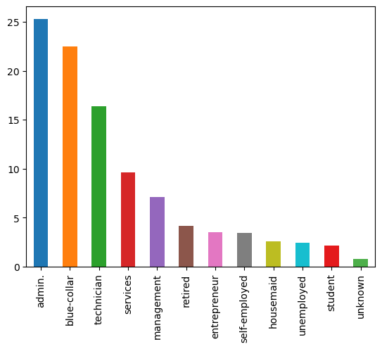

```python
round(df['job'].value_counts()/df.shape[0]*100,2).plot.bar(color=["#1f77b4", "#ff7f0e", "#2ca02c", "#d62728", "#9467bd", "#8c564b", "#e377c2", "#7f7f7f", "#bcbd22", "#17becf", "#e41a1c", "#4daf4a"])
```

## Q2) - What is the distribution of marital statuses in our dataset?

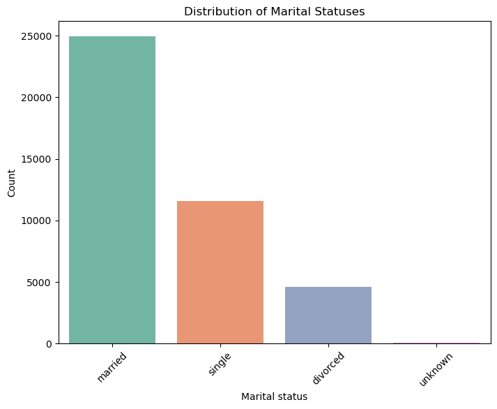

```python
plt.figure(figsize=(8, 6))
sns.countplot(data=df, x='marital', palette='Set2')
plt.xlabel('Marital status')
plt.ylabel('Count')
plt.title('Distribution of Marital Statuses')
plt.xticks(rotation=45)
plt.show()
```

## Q3) What is the ratio of different education levels among our clients?

```python
df['education'].value_counts()
```

```
university.degree      12168
high.school             9515
basic.9y                6045
professional.course     5243
basic.4y                4176
basic.6y                2292
unknown                 1731
illiterate                18
Name: education, dtype: int64
```

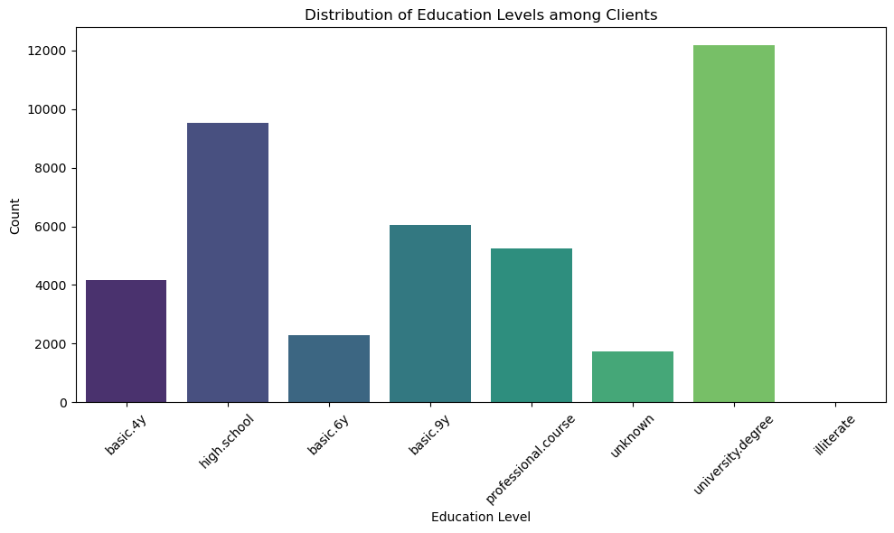

```python
plt.figure(figsize=(10, 6))
sns.countplot(data=df, x='education', palette='viridis')
plt.xlabel('Education Level')
plt.ylabel('Count')
plt.title('Distribution of Education Levels among Clients')
plt.xticks(rotation=45)
plt.tight_layout()
plt.show()
```

## Q4) What percentage of clients have credit in default?

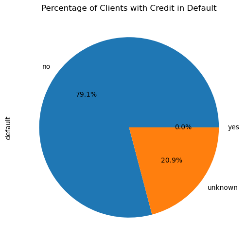

```python
plt.figure(figsize=(6, 6))
df['default'].value_counts().plot.pie(autopct='%1.1f%%')
plt.title('Percentage of Clients with Credit in Default')
plt.show()
```

```python
df['default'].value_counts()
```

```
no         32588
unknown     8597
yes            3
Name: default, dtype: int64
```

###### only 3 clients have credit that's why it's cosidered 0% in the pie chart .. too little.

## Q5) - What is the housing loan distribution among our clients?

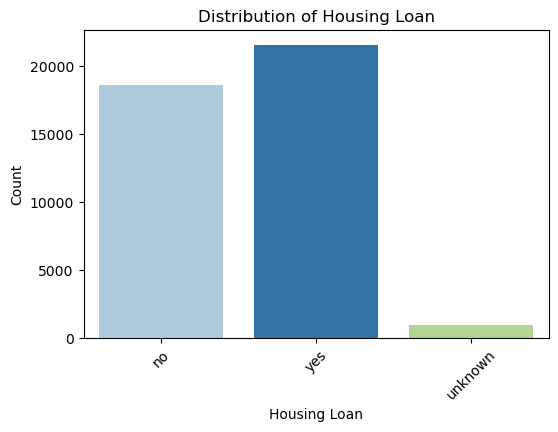

```python
plt.figure(figsize=(6, 4))
sns.countplot(data=df, x='housing', palette='Paired')
plt.xlabel('Housing Loan')
plt.ylabel('Count')
plt.title('Distribution of Housing Loan')
plt.xticks(rotation=45)
plt.show()
```

## Q6) - How many clients have personal loans and how many don't?

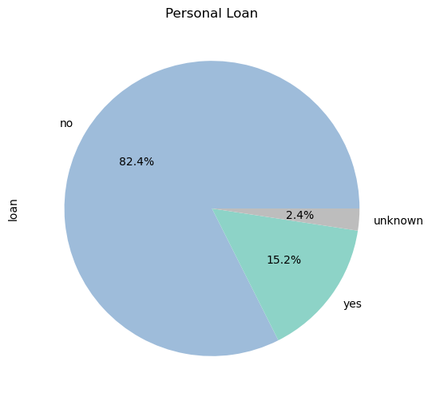

```python
plt.figure(figsize=(6, 6))
df['loan'].value_counts().plot.pie(autopct='%1.1f%%',colors=['#9ebcda','#8dd3c7','#bdbdbd'])
plt.title('Personal Loan')
plt.show()
```

## Q7) What is the most common contact communication type used for marketing?

```python
df['contact'].value_counts().idxmax()
```

```
'cellular'
```

## Q8) How many clients were contacted in each month for marketing purposes?

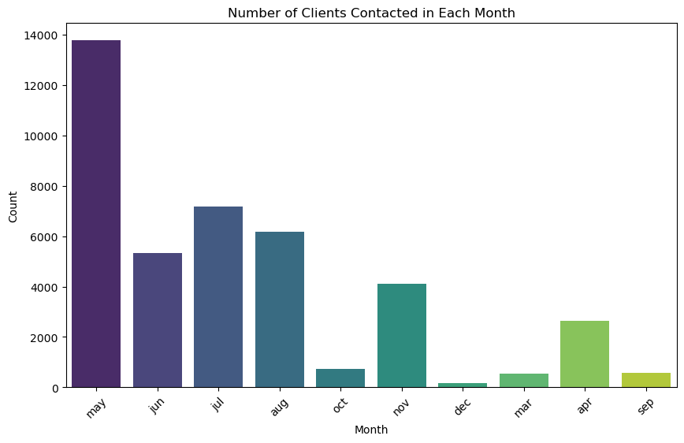

```python
plt.figure(figsize=(10, 6))
sns.countplot(data=df, x='month', palette='viridis')
plt.title('Number of Clients Contacted in Each Month')
plt.xlabel('Month')
plt.ylabel('Count')
plt.xticks(rotation=45)
plt.show()
```

```python
# displaying the exact number of contacts per mionth
month_counts = df['month'].value_counts().sort_index()
month_counts
```

```
apr     2632
aug     6178
dec      182
jul     7174
jun     5318
mar      546
may    13769
nov     4101
oct      718
sep      570
Name: month, dtype: int64
```

## Q9) What is the distribution of the last contact day of the week?

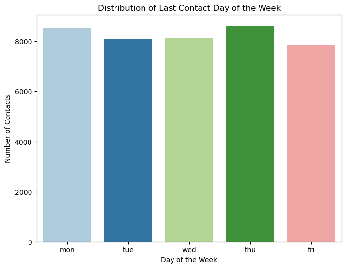

```python
plt.figure(figsize=(8, 6))
sns.countplot(data=df, x='day_of_week',palette='Paired')
plt.xlabel('Day of the Week')
plt.ylabel('Number of Contacts')
plt.title('Distribution of Last Contact Day of the Week')
plt.show()
```

## Q10 ) What is the average duration of the last contact during the campaign?

```python
average_duration = df['duration'].mean()
average_duration # in seconds
```

```
258.2850101971448
```

## Q11) How many contacts were performed during this campaign for each client?

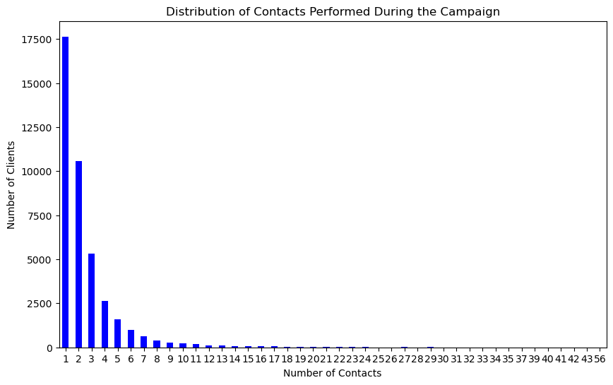

```python
contact_counts = df['campaign'].value_counts()
plt.figure(figsize=(10, 6))
contact_counts.sort_index().plot(kind='bar', color='blue')
plt.xlabel('Number of Contacts')
plt.ylabel('Number of Clients')
plt.title('Distribution of Contacts Performed During the Campaign')
plt.xticks(rotation=0)
plt.show()
```

```python
contact_counts = df['campaign'].value_counts()
print(contact_counts)
```

```
1     17642
2     10570
3      5341
4      2651
5      1599
6       979
7       629
8       400
9       283
10      225
11      177
12      125
13       92
14       69
17       58
```

[output cut: 28 more lines]

## Q12) What is the ratio of clients who subscribed to a term deposit ('yes') compared to those who didn't ('no')?

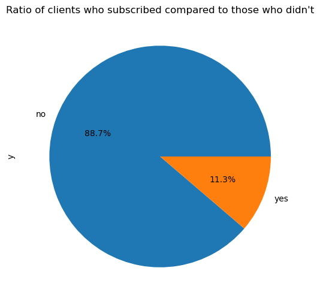

```python
plt.figure(figsize=(6, 6))
df['y'].value_counts().plot.pie(autopct='%1.1f%%')
plt.title("Ratio of clients who subscribed compared to those who didn't")
plt.show()
```

## Q13) Show the distribution of ages among the clients?

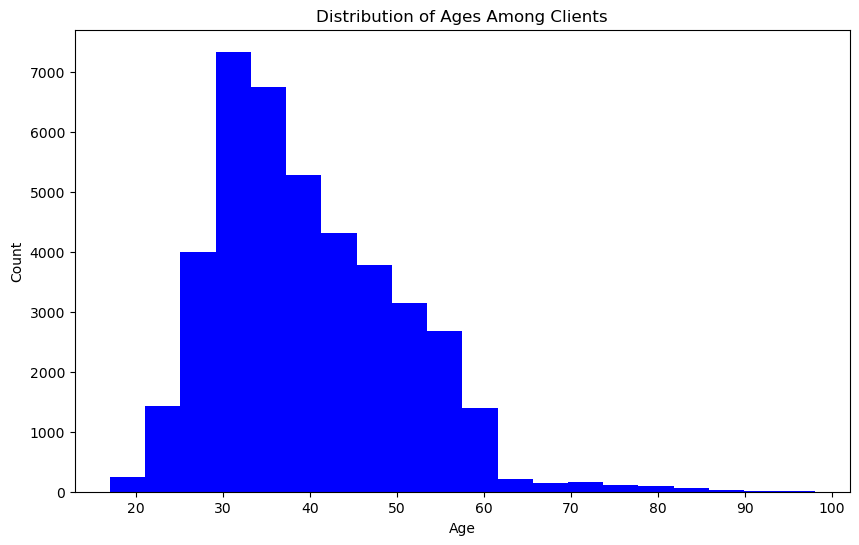

```python
plt.figure(figsize=(10, 6))
plt.hist(df['age'], bins=20, color='blue')
plt.xlabel('Age')
plt.ylabel('Count')
plt.title('Distribution of Ages Among Clients')
plt.show()
```

## Q14) Compare the subscription rates between different job types.

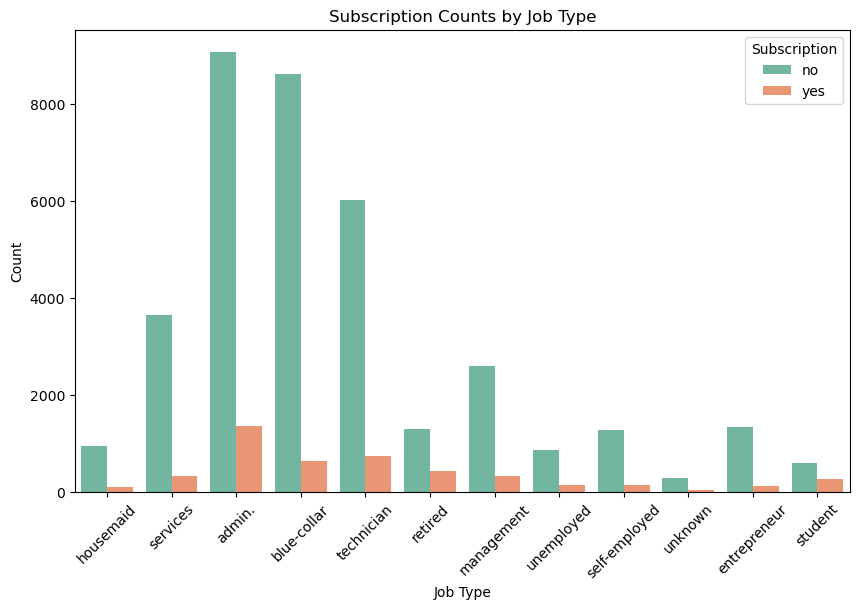

```python
plt.figure(figsize=(10, 6))
sns.countplot(data=df, x='job', hue='y',palette='Set2')
plt.xlabel('Job Type')
plt.ylabel('Count')
plt.title('Subscription Counts by Job Type')
plt.xticks(rotation=45)
plt.legend(title='Subscription')
plt.show()
```

## Q15) Which communication way (cellular, telephone) have the highest subscription rates for term deposits?

```python
subscription_rates = df.groupby('contact')['y'].value_counts(normalize=True)
cellular_rate = subscription_rates['cellular']['yes']
telephone_rate = subscription_rates['telephone']['yes']
print(f"Subscription rate for Cellular: {cellular_rate:.2%}")
print(f"Subscription rate for Telephone: {telephone_rate:.2%}")
```

```
Subscription rate for Cellular: 14.74%
Subscription rate for Telephone: 5.23%
```

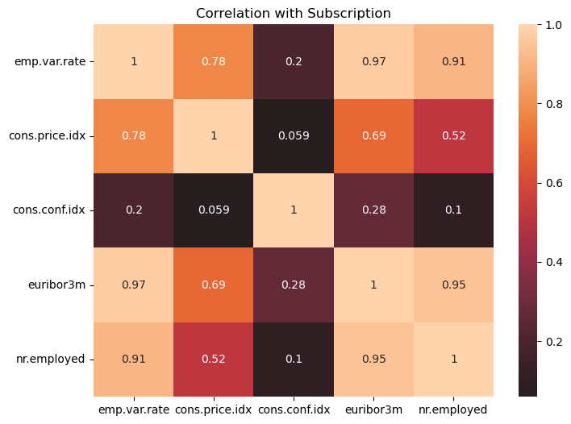

```python
features = ['emp.var.rate', 'cons.price.idx', 'cons.conf.idx', 'euribor3m', 'nr.employed','y']
plt.figure(figsize=(8, 6))
sns.heatmap(df[features].corr(), annot=True, center=0)
plt.title('Correlation with Subscription')
plt.show()
```

## Q16) Does past campaign success affect the current campaign?

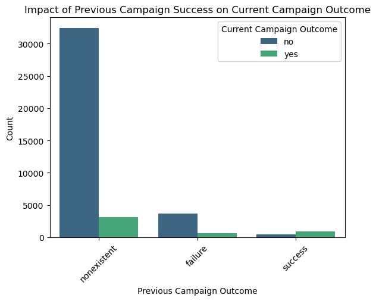

```python
sns.countplot(data=df, x='poutcome', hue='y', palette='viridis')
plt.xlabel('Previous Campaign Outcome')
plt.ylabel('Count')
plt.title('Impact of Previous Campaign Success on Current Campaign Outcome')
plt.xticks(rotation=45)
plt.legend(title='Current Campaign Outcome')
plt.show()
```

```python
df.columns
```

```
Index(['age', 'job', 'marital', 'education', 'default', 'housing', 'loan',
       'contact', 'month', 'day_of_week', 'duration', 'campaign', 'pdays',
       'previous', 'poutcome', 'emp.var.rate', 'cons.price.idx',
       'cons.conf.idx', 'euribor3m', 'nr.employed', 'y'],
      dtype='object')
```

## Q17) - How does the day of the week impact marketing campaign success?

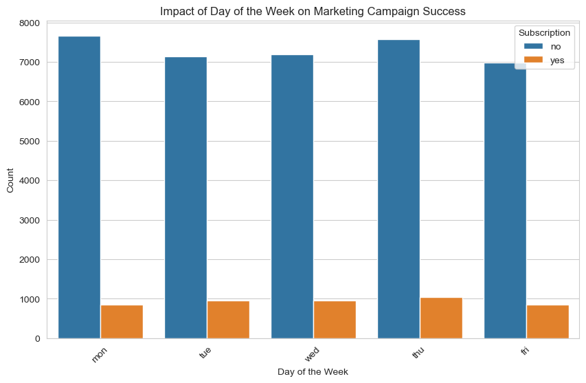

```python
plt.figure(figsize=(10, 6))
sns.countplot(data=df, x='day_of_week', hue='y')
plt.xlabel('Day of the Week')
plt.ylabel('Count')
plt.title('Impact of Day of the Week on Marketing Campaign Success')
plt.xticks(rotation=45)
plt.legend(title='Subscription')
plt.show()
```

#### the best day to make a call is likely to be Thursday

## Q18) What impact does the duration of contact have on the subscription decision?

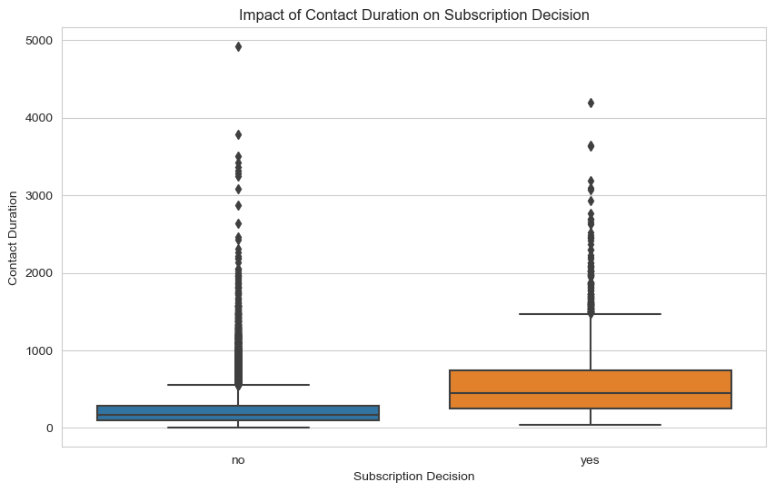

```python
plt.figure(figsize=(10, 6))
sns.boxplot(data=df, x='y', y='duration')
plt.xlabel('Subscription Decision')
plt.ylabel('Contact Duration')
plt.title('Impact of Contact Duration on Subscription Decision')
plt.show()
```

## Q19) what's the imapct of marital status and education level on the subscription rates ?

[figure not shown]

```python
plt.figure(figsize=(10, 6))
sns.countplot(data=df, x='education', hue='y',palette='Set2')
plt.xlabel('Job Type')
plt.ylabel('Count')
plt.title('Subscription Counts by Job Type')
plt.xticks(rotation=45)
plt.legend(title='Subscription')
plt.show()
```

[figure not shown]

```python
plt.figure(figsize=(10, 6))
sns.countplot(data=df, x='marital', hue='y',palette='Paired')
plt.xlabel('Job Type')
plt.ylabel('Count')
plt.title('Subscription Counts by Job Type')
plt.xticks(rotation=45)
plt.legend(title='Subscription')
plt.show()
```